# **Tugas Pendat**

**langkah-langkah data mining**

1. bisnis understanding
2. data understanding : tau outlier(data kotor),missing values
3. preprocecing
4. modeling 5.evaluasi 6.deployement

# **Macam-macam data pada datamining**

**1.Berdasarkan Sifat Datanya**

1. Data Numerik (Numerical Data): Data dalam bentuk angka yang dapat diolah secara matematis.
2. Data Kategorikal (Categorical Data): Data dalam bentuk kategori atau label yang tidak memiliki nilai numerik.
3. Data Ordinal: Data yang memiliki urutan atau tingkatan, tetapi selisih antara nilainya tidak harus sama.
4. Data Boolean: Data yang hanya memiliki dua kemungkinan nilai (true/false atau 0/1).

**2. Berdasarkan Sumber Datanya**

1. Data Terstruktur (Structured Data): Data yang tersimpan dalam format yang terorganisir, seperti tabel dalam database relasional.
2. Data Semi-Terstruktur (Semi-Structured Data): Data yang tidak sepenuhnya terstruktur tetapi memiliki elemen yang bisa dikenali.
3. Data Tidak Terstruktur (Unstructured Data): Data yang tidak memiliki format baku dan sulit dimasukkan ke dalam tabel database.

**3. Berdasarkan Sumber Pengumpulan**

1. Data Historis: Data yang dikumpulkan dari waktu sebelumnya untuk analisis tren atau prediksi.
2. Data Real-Time: Data yang dikumpulkan dan dianalisis secara langsung saat terjadi.

**4. Berdasarkan Fungsinya dalam Data Mining**

1. Data Training (Training Data): Data yang digunakan untuk melatih model machine learning.
2. Data Uji (Testing Data): Data yang digunakan untuk menguji performa model yang telah dilatih.
3. Data Validasi (Validation Data): Data yang digunakan untuk menyempurnakan model sebelum digunakan pada data uji.

# **Langkah-Langkah menghubungkan database dbeaver ke aiven.io dan ditampilkan pada google colab**

**Langkah-Langkah :**

1. membuat akun aiven.io setelah itu membuat project untuk mysql dan postgresql
2. download dbeaver dan membuat database baru, hubungkan dengan project di aiven.io, hubungkan dengan menyeseuaikan (hostname,username,password,port).
3. import data pada database dbeaver yang sudah dibuat yaitu pada database mysql dan postgresql dengan cara import data menggunakan file csv yang sudah diberikan. pada sql membuat tabel terlebih dahulu dan menyesuaikan dengan file yang akan di upload pada kolom tabel, untuk postgreSQL tidak perlu membuat tabel.

```python
# Langkah 3: Instal library yang diperlukan
# sqlalchemy: untuk membuat koneksi ke database
# pymysql: untuk koneksi ke database MySQL
# psycopg2-binary: untuk koneksi ke database PostgreSQL
!pip install sqlalchemy pymysql psycopg2-binary
```

```python
# Langkah 4: Import library yang diperlukan
import pandas as pd
from sqlalchemy import create_engine
```

```python
# langkah 5 koneksi ke database untuk mengambil data
# Connection string untuk database MySQL
mysql_connection_str = "mysql+pymysql://avnadmin:AVNS_sCqSEQNPDXAgnk-Hdm_@mysql-19129d6b-irismysqlpendata.i.aivencloud.com:11008/defaultdb"

# Connection string untuk database PostgreSQL
postgres_connection_str = "postgresql+psycopg2://avnadmin:AVNS_gGZBlpF7RgYXMia9bTl@pg-1c61c4b9-irispostgresql.i.aivencloud.com:16652/defaultdb"
```

```python
# langkah 6
from sqlalchemy import create_engine

# Membuat engine untuk MySQL
engine_mysql = create_engine(mysql_connection_str)

# Membuat engine untuk PostgreSQL
engine_postgres = create_engine(postgres_connection_str)
```

```python
# langkah 7 mengambil data dari tabel
import pandas as pd

query_mysql = "SELECT * FROM IRISMYSQL"  # Ganti nama tabel sesuai kebutuhan
query_postgres = "SELECT * FROM irispostgres"  # Ganti nama tabel sesuai kebutuhan

df_mysql = pd.read_sql(query_mysql, con=engine_mysql)
df_postgres = pd.read_sql(query_postgres, con=engine_postgres)
```

# **menggabungkan data dari 2 database berbeda**

```python
# langkah 8 menampilkan tabel yang sudah digabungkan
# Import library
import pandas as pd
from sqlalchemy import create_engine

engine_mysql = create_engine(mysql_connection_str)
engine_postgres = create_engine(postgres_connection_str)

# Ambil data dari masing-masing database
query_mysql = "SELECT * FROM IRISMYSQL"
query_postgres = "SELECT * FROM irispostgres"

df_mysql = pd.read_sql(query_mysql, con=engine_mysql)
df_postgres = pd.read_sql(query_postgres, con=engine_postgres)

# Pastikan nama kolom konsisten sebelum merge
df_mysql.rename(columns={'class': 'Class'}, inplace=True)

# Gabungkan data berdasarkan 'id' dan 'Class'
df_merged = pd.merge(df_mysql, df_postgres, on=["id", "Class"], how="outer", suffixes=('_mysql', '_postgres'))

# Tampilkan jumlah total baris
print(f"\n📊 Total Data Setelah Merge: {df_merged.shape[0]} baris, {df_merged.shape[1]} kolom\n")

# Styling tabel untuk tampilan lebih menarik
styled_table = df_merged.style.background_gradient(cmap='viridis')

# Tampilkan tabel dalam Jupyter Notebook atau Google Colab
display(styled_table)
```

```
📊 Total Data Setelah Merge: 150 baris, 6 kolom
```

|  | id | Class | petal_length | petal_width | sepal_length | sepal_width |
| --- | --- | --- | --- | --- | --- | --- |
| 0 | 1 | Iris-setosa | 86.400000 | 70.000000 | 20.100000 | 30.500000 |
| 1 | 2 | Iris-setosa | 1.400000 | 0.200000 | 4.900000 | 3.000000 |
| 2 | 3 | Iris-setosa | 1.300000 | 0.200000 | 4.700000 | 3.200000 |
| 3 | 4 | Iris-setosa | 1.500000 | 0.200000 | 4.600000 | 3.100000 |
| 4 | 5 | Iris-setosa | 1.400000 | 0.200000 | 5.000000 | 3.600000 |
| 5 | 6 | Iris-setosa | 1.700000 | 0.400000 | 5.400000 | 3.900000 |
| 6 | 7 | Iris-setosa | 1.400000 | 0.300000 | 4.600000 | 3.400000 |
| 7 | 8 | Iris-setosa | 1.500000 | 0.200000 | 5.000000 | 3.400000 |
| 8 | 9 | Iris-setosa | 1.400000 | 0.200000 | 4.400000 | 2.900000 |
| 9 | 10 | Iris-setosa | 1.500000 | 0.100000 | 4.900000 | 3.100000 |
| 10 | 11 | Iris-setosa | 1.500000 | 0.200000 | 5.400000 | 3.700000 |
| 11 | 12 | Iris-setosa | 1.600000 | 0.200000 | 4.800000 | 3.400000 |
| 12 | 13 | Iris-setosa | 1.400000 | 0.100000 | 4.800000 | 3.000000 |
| 13 | 14 | Iris-setosa | 1.100000 | 0.100000 | 4.300000 | 3.000000 |
| 14 | 15 | Iris-setosa | 1.200000 | 0.200000 | 5.800000 | 4.000000 |
| 15 | 16 | Iris-setosa | 1.500000 | 0.400000 | 5.700000 | 4.400000 |
| 16 | 17 | Iris-setosa | 1.300000 | 0.400000 | 5.400000 | 3.900000 |
| 17 | 18 | Iris-setosa | 1.400000 | 0.300000 | 5.100000 | 3.500000 |
| 18 | 19 | Iris-setosa | 1.700000 | 0.300000 | 5.700000 | 3.800000 |
| 19 | 20 | Iris-setosa | 1.500000 | 0.300000 | 5.100000 | 3.800000 |
| 20 | 21 | Iris-setosa | 1.700000 | 0.200000 | 5.400000 | 3.400000 |
| 21 | 22 | Iris-setosa | 1.500000 | 0.400000 | 5.100000 | 3.700000 |
| 22 | 23 | Iris-setosa | 1.000000 | 0.200000 | 4.600000 | 3.600000 |
| 23 | 24 | Iris-setosa | 1.700000 | 0.500000 | 5.100000 | 3.300000 |
| 24 | 25 | Iris-setosa | 1.900000 | 0.200000 | 4.800000 | 3.400000 |
| 25 | 26 | Iris-setosa | 1.600000 | 0.200000 | 5.000000 | 3.000000 |
| 26 | 27 | Iris-setosa | 1.600000 | 0.400000 | 5.000000 | 3.400000 |
| 27 | 28 | Iris-setosa | 1.500000 | 0.200000 | 5.200000 | 3.500000 |
| 28 | 29 | Iris-setosa | 1.400000 | 0.200000 | 5.200000 | 3.400000 |
| 29 | 30 | Iris-setosa | 1.600000 | 0.200000 | 4.700000 | 3.200000 |

[output cut: 120 more lines]

# **Menampilkan Statistik**

```python
# langkah 9 menghitung dan menampilkan statistik
import pandas as pd

# Hitung statistik deskriptif
stats = df_merged.describe()

# Styling tabel statistik deskriptif
styled_stats = stats.style.background_gradient(cmap='viridis')

# Tampilkan
print("Statistik Deskriptif:")
display(styled_stats)
```

```
Statistik Deskriptif:
```

|  | id | petal_length | petal_width | sepal_length | sepal_width |
| --- | --- | --- | --- | --- | --- |
| count | 150.000000 | 150.000000 | 150.000000 | 150.000000 | 150.000000 |
| mean | 75.500000 | 4.325333 | 1.664000 | 5.943333 | 3.234000 |
| std | 43.445368 | 6.970563 | 5.668070 | 1.426895 | 2.282464 |
| min | 1.000000 | 1.000000 | 0.100000 | 4.300000 | 2.000000 |
| 25% | 38.250000 | 1.600000 | 0.300000 | 5.100000 | 2.800000 |
| 50% | 75.500000 | 4.400000 | 1.300000 | 5.800000 | 3.000000 |
| 75% | 112.750000 | 5.100000 | 1.800000 | 6.400000 | 3.300000 |
| max | 150.000000 | 86.400000 | 70.000000 | 20.100000 | 30.500000 |

```python
# langkah 10 Menghitung median hanya untuk kolom numerik
print("\nMedian per kolom numerik:")
median_values = df_merged.select_dtypes(include=['number']).median()

# Mengubah Series median menjadi DataFrame untuk styling
median_df = median_values.to_frame(name='Median')

# Styling tabel median menggunakan background_gradient
styled_median = median_df.style.background_gradient(cmap='viridis')

# Tampilkan tabel median dengan styling
from IPython.display import display
display(styled_median)
```

```
Median per kolom numerik:
```

|  | Median |
| --- | --- |
| id | 75.500000 |
| petal_length | 4.400000 |
| petal_width | 1.300000 |
| sepal_length | 5.800000 |
| sepal_width | 3.000000 |

# **Menampilkan Fitur-Fitur seperti pada orange**

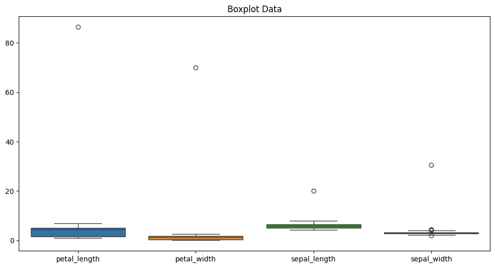

```python
# fitur boxplot
# langkah 11 Boxplot untuk melihat distribusi data per kolom
plt.figure(figsize=(12, 6))
sns.boxplot(data=df_merged[['petal_length', 'petal_width', 'sepal_length', 'sepal_width']])
plt.title("Boxplot Data")
plt.show()
```

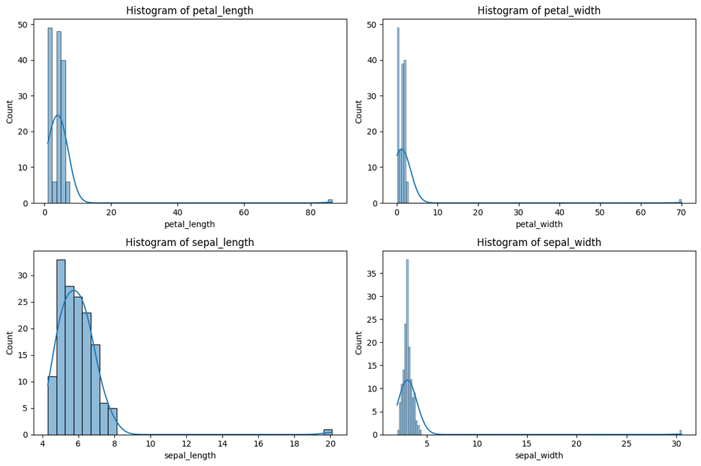

```python
# Fitur histogram
#langkah 12 menampilkan histogram untuk masing-masing kolom
fig, axes = plt.subplots(2, 2, figsize=(12, 8))
columns = ['petal_length', 'petal_width', 'sepal_length', 'sepal_width']
for ax, col in zip(axes.flatten(), columns):
    sns.histplot(df_merged[col], kde=True, ax=ax)
    ax.set_title(f'Histogram of {col}')
plt.tight_layout()
plt.show()
```

```python
# langkah 13 menampilkan pivot table ranking
import pandas as pd

# Buat pivot table untuk menghitung rata-rata petal_length per Class
pivot_table = pd.pivot_table(
    df_merged,
    values='petal_length',  # Nilai yang dihitung rata-ratanya
    index='Class',          # Kelompok berdasarkan Class
    aggfunc='mean'          # Fungsi agregasi: mean
)

# Urutkan pivot table berdasarkan nilai petal_length secara menurun
pivot_table = pivot_table.sort_values(by='petal_length', ascending=False)

# Tambahkan kolom peringkat (rank) berdasarkan nilai petal_length
pivot_table['Rank'] = pivot_table['petal_length'].rank(method='dense', ascending=False).astype(int)

# Reset index agar kolom Class muncul sebagai kolom biasa
pivot_table = pivot_table.reset_index()

# Styling untuk tampilan yang lebih menarik
styled_pivot_table = pivot_table.style.background_gradient(cmap='plasma') \
    .set_caption("📊 Pivot Table dengan Ranking") \
    .set_properties(**{'text-align': 'center'}) \
    .format({'petal_length': "{:.2f}"})  # Format angka menjadi 2 desimal

# Tampilkan Pivot Table
display(styled_pivot_table)
```

📊 Pivot Table dengan Ranking

|  | Class | petal_length | Rank |
| --- | --- | --- | --- |
| 0 | Iris-virginica | 5.55 | 1 |
| 1 | Iris-versicolor | 4.26 | 2 |
| 2 | Iris-setosa | 3.16 | 3 |

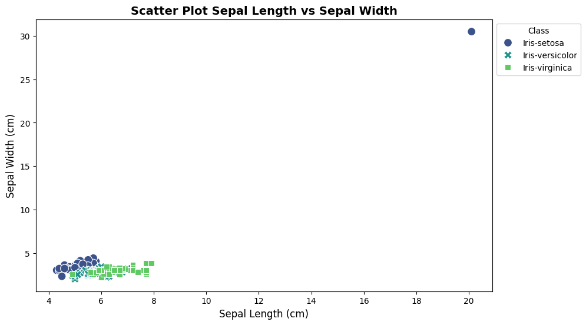

```python
# fitur scatter plot
# langkah 14 menampilkan scetter plot
import matplotlib.pyplot as plt
import seaborn as sns

# Set ukuran figure
plt.figure(figsize=(10, 6))

# Scatter plot menggunakan seaborn
sns.scatterplot(
    data=df_merged,
    x="sepal_length",
    y="sepal_width",
    hue="Class",
    style="Class",
    palette="viridis",
    s=100  # Ukuran titik
)

# Tambahkan judul dan label sumbu
plt.title("Scatter Plot Sepal Length vs Sepal Width", fontsize=14, fontweight="bold")
plt.xlabel("Sepal Length (cm)", fontsize=12)
plt.ylabel("Sepal Width (cm)", fontsize=12)

# Tambahkan legend di lokasi terbaik
plt.legend(title="Class", bbox_to_anchor=(1, 1), loc="upper left")

# Tampilkan plot
plt.show()
```

```python
# langkah 15 menampilkan statistik lengkap
import pandas as pd
from IPython.display import display

# Pilih hanya kolom numerik
numerical_columns = df_merged.select_dtypes(include=['number'])

# Hitung statistik deskriptif dasar
stats = numerical_columns.describe().T  # Transpose agar lebih rapi

# Tambahkan statistik tambahan
stats['Median'] = numerical_columns.median()
stats['Mode'] = numerical_columns.mode().iloc[0]  # Mode bisa lebih dari satu, ambil yang pertama
stats['Variance'] = numerical_columns.var()
stats['Missing Values'] = numerical_columns.isnull().sum()

# Styling tabel statistik deskriptif
styled_stats = stats.style.background_gradient(cmap='coolwarm')\
                        .set_table_attributes("style='width:80%;'")\
                        .set_caption("📊 Statistik Deskriptif Lengkap")\
                        .format(precision=2)  # Menampilkan 2 angka di belakang koma

# Tampilkan tabel statistik deskriptif
display(styled_stats)
```

📊 Statistik Deskriptif Lengkap

|  | count | mean | std | min | 25% | 50% | 75% | max | Median | Mode | Variance | Missing Values |
| --- | --- | --- | --- | --- | --- | --- | --- | --- | --- | --- | --- | --- |
| id | 150.00 | 75.50 | 43.45 | 1.00 | 38.25 | 75.50 | 112.75 | 150.00 | 75.50 | 1.00 | 1887.50 | 0 |
| petal_length | 150.00 | 4.33 | 6.97 | 1.00 | 1.60 | 4.40 | 5.10 | 86.40 | 4.40 | 1.50 | 48.59 | 0 |
| petal_width | 150.00 | 1.66 | 5.67 | 0.10 | 0.30 | 1.30 | 1.80 | 70.00 | 1.30 | 0.20 | 32.13 | 0 |
| sepal_length | 150.00 | 5.94 | 1.43 | 4.30 | 5.10 | 5.80 | 6.40 | 20.10 | 5.80 | 5.00 | 2.04 | 0 |
| sepal_width | 150.00 | 3.23 | 2.28 | 2.00 | 2.80 | 3.00 | 3.30 | 30.50 | 3.00 | 3.00 | 5.21 | 0 |

# **Menemukan Outlier (Data Kotor)**

**metode menemukan outlier**

1. KNN (k-nearest neighbor ): bisa digunakan untuk menebak label dan menebak kelas digunakan untuk menemukan outlier juga, Tujuan dari algoritma k-nearest neighbor adalah untuk mengidentifikasi tetangga terdekat dari titik kueri yang diberikan, sehingga kita dapat menetapkan label kelas ke titik tersebut.
   - klasifikasi kalo label itu tidak angka (yang ditebak adalah class)
   - regresi data label atau class adalah angka (yang ditebak adalah angka)

**Langkah-Langkah KNN**

1. Hitung jarak antara data baru dan semua data dalam dataset
2. pilih K tetangga terdekat
3. untuk klasifikasi : Ambil mayoritas kelas dari K tetangga
4. untuk regresi : Ambil rata-rata nilai dari K tetangga.

**jenis-jenis metrik jarak**

1. Euclidean Distance :Menghitung jarak lurus (garis terpendek) antara dua titik dalam ruang Euclidean.
2. Manhattan Distance : Menghitung jarak antara dua titik dengan hanya bergerak secara horizontal dan vertikal (seperti perjalanan taksi di kota dengan jalan berbentuk grid).
3. Minkowski Distance

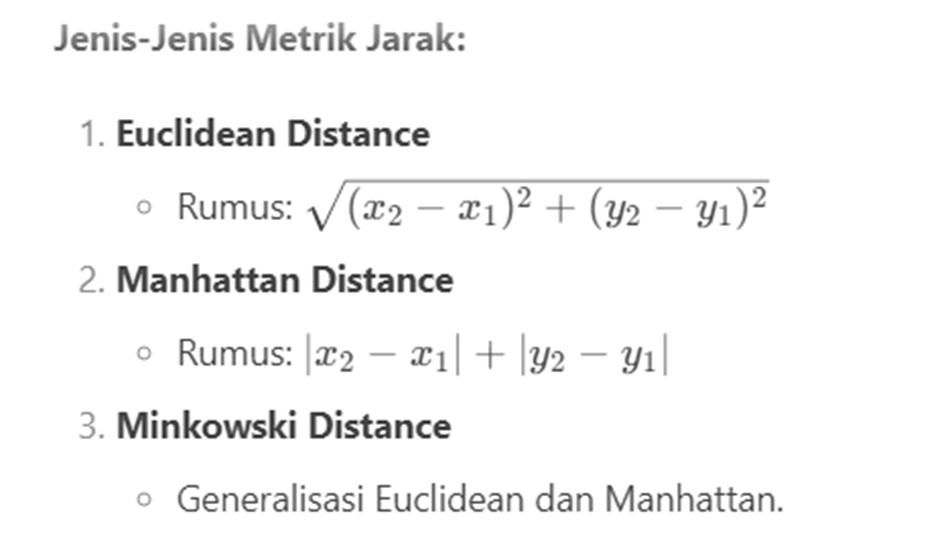

```python
# Langkah 1: Menampilkan data perhitungan manual Euclidean Distance dan ranknya
# Import library
import pandas as pd
from sqlalchemy import create_engine

# 🔹 Koneksi ke database PostgreSQL
postgres_connection_str = "postgresql+psycopg2://avnadmin:AVNS_gGZBlpF7RgYXMia9bTl@pg-1c61c4b9-irispostgresql.i.aivencloud.com:16652/defaultdb"
engine_postgres = create_engine(postgres_connection_str)

# 🔹 Ambil data dari tabel datahitung di PostgreSQL
query_postgres = "SELECT * FROM datahitung"
df_postgres = pd.read_sql(query_postgres, con=engine_postgres)

# 🔹 Tampilkan jumlah total baris
print(f"\n📊 Total Data: {df_postgres.shape[0]} baris, {df_postgres.shape[1]} kolom\n")

# 🔹 Styling tabel untuk tampilan lebih menarik
styled_table = df_postgres.style.background_gradient(cmap='viridis')

# 🔹 Tampilkan tabel dalam Jupyter Notebook atau Google Colab
display(styled_table)
```

```
📊 Total Data: 150 baris, 8 kolom
```

|  | id | Class | petal_length | petal_width | sepal_length | sepal_width | EUCLEDIAN | RANK |
| --- | --- | --- | --- | --- | --- | --- | --- | --- |
| 0 | 1 | Iris-setosa | 86,4 | 70 | 20,1 | 30,5 | 114,3867562 | 11 |
| 1 | 2 | Iris-setosa | 1,4 | 0,2 | 4,9 | 3 | 114,4399406 | 10 |
| 2 | 3 | Iris-setosa | 1,3 | 0,2 | 4,7 | 3,2 | 114,3287365 | 15 |
| 3 | 4 | Iris-setosa | 1,5 | 0,2 | 4,6 | 3,1 | 114,2307314 | 20 |
| 4 | 5 | Iris-setosa | 1,4 | 0,2 | 5 | 3,6 | 113,7624718 | 44 |
| 5 | 6 | Iris-setosa | 1,7 | 0,4 | 5,4 | 3,9 | 114,2705124 | 16 |
| 6 | 7 | Iris-setosa | 1,4 | 0,3 | 4,6 | 3,4 | 114,2036339 | 22 |
| 7 | 8 | Iris-setosa | 1,5 | 0,2 | 5 | 3,4 | 114,4783386 | 7 |
| 8 | 9 | Iris-setosa | 1,4 | 0,2 | 4,4 | 2,9 | 114,3495518 | 10 |
| 9 | 10 | Iris-setosa | 1,5 | 0,1 | 4,9 | 3,1 | 114,0805856 | 26 |
| 10 | 11 | Iris-setosa | 1,5 | 0,2 | 5,4 | 3,7 | 114,155946 | 23 |
| 11 | 12 | Iris-setosa | 1,6 | 0,2 | 4,8 | 3,4 | 114,4611288 | 8 |
| 12 | 13 | Iris-setosa | 1,4 | 0,1 | 4,8 | 3 | 114,7518627 | 2 |
| 13 | 14 | Iris-setosa | 1,1 | 0,1 | 4,3 | 3 | 114,1832737 | 19 |
| 14 | 15 | Iris-setosa | 1,2 | 0,2 | 5,8 | 4 | 113,7573734 | 35 |
| 15 | 16 | Iris-setosa | 1,5 | 0,4 | 5,7 | 4,4 | 114,0605979 | 23 |
| 16 | 17 | Iris-setosa | 1,3 | 0,4 | 5,4 | 3,9 | 114,1800771 | 19 |
| 17 | 18 | Iris-setosa | 1,4 | 0,3 | 5,1 | 3,5 | 113,8087431 | 32 |
| 18 | 19 | Iris-setosa | 1,7 | 0,3 | 5,7 | 3,8 | 114,0350385 | 22 |
| 19 | 20 | Iris-setosa | 1,5 | 0,3 | 5,1 | 3,8 | 114,0027631 | 26 |
| 20 | 21 | Iris-setosa | 1,7 | 0,2 | 5,4 | 3,4 | 113,9974123 | 26 |
| 21 | 22 | Iris-setosa | 1,5 | 0,4 | 5,1 | 3,7 | 114,5821103 | 3 |
| 22 | 23 | Iris-setosa | 1 | 0,2 | 4,6 | 3,6 | 113,8823077 | 26 |
| 23 | 24 | Iris-setosa | 1,7 | 0,5 | 5,1 | 3,3 | 113,9332699 | 25 |
| 24 | 25 | Iris-setosa | 1,9 | 0,2 | 4,8 | 3,4 | 114,2249535 | 15 |
| 25 | 26 | Iris-setosa | 1,6 | 0,2 | 5 | 3 | 114,007105 | 23 |
| 26 | 27 | Iris-setosa | 1,6 | 0,4 | 5 | 3,4 | 114,1536684 | 17 |
| 27 | 28 | Iris-setosa | 1,5 | 0,2 | 5,2 | 3,5 | 114,2517396 | 13 |
| 28 | 29 | Iris-setosa | 1,4 | 0,2 | 5,2 | 3,4 | 114,2170303 | 14 |
| 29 | 30 | Iris-setosa | 1,6 | 0,2 | 4,7 | 3,2 | 114,2275361 | 13 |

[output cut: 120 more lines]

```python
# langkah 2 menemukan outlier ekstreme pada data
# 📌 Import library yang diperlukan
import numpy as np
import matplotlib.pyplot as plt
import pandas as pd
from sklearn.neighbors import NearestNeighbors  # Model KNN untuk mendeteksi outlier

# Pilih hanya kolom numerik dari data yang telah digabungkan (df_merged)
numerical_columns = df_merged.select_dtypes(include=[np.number]).columns

# Periksa apakah ada kolom numerik dalam dataset
if len(numerical_columns) == 0:
    print("⚠ Tidak ada kolom numerik untuk dianalisis.")
else:
    # Ambil hanya nilai numerik dari dataset untuk analisis outlier
    X = df_merged[numerical_columns].values

    # Tangani nilai NaN dengan menggantinya menggunakan nilai median dari setiap kolom
    X = np.nan_to_num(X, nan=np.nanmedian(X))

    # Tentukan jumlah tetangga (k) berdasarkan aturan umum: k = akar jumlah data
    k = max(3, int(np.sqrt(len(X))))  # Minimal k=3 untuk memastikan stabilitas perhitungan

    # Latih model KNN dan cari k tetangga terdekat untuk setiap data
    nbrs = NearestNeighbors(n_neighbors=k+1).fit(X)
    distances, indices = nbrs.kneighbors(X)

    # Ambil rata-rata jarak dari k tetangga terdekat (mengabaikan titik data itu sendiri)
    avg_distances = distances[:, 1:].mean(axis=1)

    # Tentukan threshold untuk mendeteksi outlier menggunakan persentil 99.5
    #    Semakin tinggi persentil, semakin ketat deteksi outlier
    threshold = np.percentile(avg_distances, 99.5)

    # Temukan indeks data yang memiliki rata-rata jarak lebih besar dari threshold
    outliers = np.where(avg_distances > threshold)[0]

    # Tampilkan hasil jumlah outlier yang ditemukan
    print(f"📌 Total outliers ditemukan: {len(outliers)}\n")

    # Jika ada outlier, tampilkan indeks dan data outlier
    if len(outliers) > 0:
        print("Indeks Outliers:", outliers)
        print("\n🔍 Data Outliers:")
        display(df_merged.iloc[outliers])  # Gunakan display agar tampilan lebih rapi di Jupyter Notebook

    # Visualisasi outlier hanya jika data memiliki 2 fitur numerik (agar bisa digambarkan dalam 2D)
    if X.shape[1] == 2:
        plt.figure(figsize=(8,6))
        plt.scatter(X[:, 0], X[:, 1], label="Normal Data", alpha=0.6)  # Data normal
        plt.scatter(X[outliers, 0], X[outliers, 1], color='red', label="Outlier", edgecolors='k', s=100)  # Data outlier
        plt.xlabel(numerical_columns[0])
        plt.ylabel(numerical_columns[1])
        plt.title("Outlier Detection using KNN")
        plt.legend()
        plt.show()
```

```
📌 Total outliers ditemukan: 1

Indeks Outliers: [0]

🔍 Data Outliers:
```

|  | id | Class | petal_length | petal_width | sepal_length | sepal_width |
| --- | --- | --- | --- | --- | --- | --- |
| 0 | 1 | Iris-setosa | 86.4 | 70.0 | 20.1 | 30.5 |

**Proses Penghitungan Outlier**

**Kenapa Outlier Dihitung Berdasarkan Jarak?**

1. Data yang jauh dari kelompoknya akan memiliki rata-rata jarak lebih tinggi ke tetangga terdekatnya.
2. Data yang terisolasi atau tidak memiliki banyak tetangga dekat juga akan memiliki rata-rata jarak lebih tinggi.
3. Dengan menggunakan persentil, kita hanya mengambil sebagian kecil data yang benar-benar memiliki jarak ekstrem.

```python
!jupyter nbconvert --to html tugaspendat1.ipynb
```

```
[NbConvertApp] Converting notebook tugaspendat1.ipynb to html
[NbConvertApp] WARNING | Alternative text is missing on 4 image(s).
[NbConvertApp] Writing 672049 bytes to tugaspendat1.html
```

```python
from google.colab import files
files.download("tugaspendat1.html")
```